# Analysis of New York AP/IB 2023-2024 Scores

## Fall 2025 Data Science Project

*Note: Our GitHub repository submitted from Checkpoint 1 has since moved to: https://github.com/cmsc320fall2025-MCAS/cmsc320-project*

## **Contributions**

Contributions: For each member, list which of the following sections they worked on, and summarize the contributions in 1-2 sentences.

Be specific!

A: Project idea

B: Dataset Curation and Preprocessing

C: Data Exploration and Summary Statistics

D: ML Algorithm Design/Development

E: ML Algorithm Training and Test Data Analysis

F: Visualization, Result Analysis, Conclusion

G: Final Tutorial Report Creation

H: Additional (not listed above)

| Name | Section | Description |
| --- | --- | --- |
| Anna Gustafson | A, B, C, D, G | Handled the dataset curation and preprocessing. Made a section under data exploration. Helped select an appropriate ML model. Began the design and primary analysis. Worked to format and edit the tutor… |
| Carlo Andanar | A, B, C, F, G | Devised the idea & motivation behind our topic and real-world applications for project Contributed to introduction & dataset curation. Wrote the second exploratory analysis & basis of conclusion. Crea… |
| Mary Abbago | A, C, D, E, F | Helped find and pick dataset. Wrote the first exploratory analysis. Created and coded the last two ML analyses. Wrote conclusion and insights. |
| Sayuri Modi | A, B, C, D, E, F, G | Helped pick dataset and project idea, wrote introduction and data curation section. Coded and wrote exploratory analysis 3, and all of the primary analysis section. Helped pick the ML algorithm (K-kme… |

## **Introduction**

AP and IB programs are a major gateway to college success and significantly contribute to student outcomes by providing an avenue for students to demonstrate college-level rigor before leaving secondary education. Students who can achieve high marks in these exams receive a head start on their collegiate careers while also strengthening both their college applications as well as scholarships opportunities.

New York State, home to one of the nation's largest and most diverse public education systems, has significant disparities in both access to and success within AP/IB programs. While some districts boast robust advanced coursework offerings and high achievement rates, others struggle to provide students with even basic access to these college-preparatory opportunities. These gaps often mirror broader patterns of educational inequity, disproportionately affecting students in under-resourced districts and those from economically disadvantaged backgrounds.

This project seeks to answer three central questions:

1. What patterns exist in AP/IB performance across New York school districts? Can we identify natural groupings of districts based on exam performance and demographic characteristics?
2. Which districts and student populations face the greatest opportunity gaps? Are certain regions or demographic groups systematically underserved in access to advanced coursework (less exams offered)?
3. What actionable insights can inform policy decisions? How can data-driven analysis help policymakers and education leaders allocate resources more effectively to support struggling districts?

### Why does this matter?

Using comprehensive AP/IB examination data from the 2023-2024 school year provided by the New York State Education Department, this analysis will employ data science techniques to uncover systemic patterns, identify at-risk districts, and ultimately contribute to more equitable educational outcomes across the state.

## **Data Curation**

The dataset we will analyze for this project is the Advanced Placement (AP) and International Baccalaureate (IB) dataset (https://data.nysed.gov/files/apib/2324/APIB24.zip), specifically AP_IB_Assessment_2024.mdb that was subsequently converted to a .csv using Microsoft Excel that was published by the New York State Education Department in 2024 (https://data.nysed.gov/downloads.php). The primary information contained in this data set are the AP and IB test scores recorded from the 2023-2024 school year in New York State. The dataset gives a full breakdown of student AP and IB exam performance, organized in multiple layers so we can analyze results from broad statewide patterns down to very specific student groups. It includes:

### Geographic Aggregation Levels

Data is reported at several levels:

- Statewide
- New York City (NYC)
- County
- School district
- “Needs/Resource” categories (e.g., high-need districts, average-need, etc.)

This lets us compare performance across regions and district types.

### Student Subgroups

Within every geographic level, results are divided into detailed demographic and educational subgroups, including:

- **Gender:** Male, Female, Nonbinary
- **Race/Ethnicity:** Hispanic, White, Black, Multiracial, American Indian, Asian/Pacific Islander
- **Program:** general education, English language learner (ELL vs non-ELL)
- **Household status:** economically disadvantaged, migrant, homeless, foster care, students with a parent in the armed forces (and their “not” counterparts)

This structure allows us to explore equity, opportunity gaps, and subgroup performance patterns.

### Exam-Level Details

For each subgroup, the dataset provides:

- **Exam Name:** (AP Bio, AP Calculus AB, IB Chem, etc)
- **Student grade level:** (9-12)
- **Score Distributions:**
  - **AP:** number of students receiving 1, 2, 3, 4, or 5
  - **IB:** number receiving 1 through 7

### Interpreting the Data

The dataset is broken down by geographic region → subgroup → exam → grade → score, repeated hundreds of thousands of times so every student who has tested in the state of NY is present once in each aggregate. It’s designed to let us analyze performance deeply—from statewide trends all the way down to the performance of specific subgroups in particular districts, grades, and exams. It provides both participation counts and score distributions, giving us everything we need to study achievement patterns and equity outcomes.

To begin we imported the following libraries and loaded in the provided CSV.

```python
# Import libraries for Data Curation
import pandas as pd
import numpy as np
import scipy.stats as stats
import matplotlib.pyplot as plt
import seaborn as sns
```

```python
# Load CSV
df = pd.read_csv("/content/sample_data/AP_IB_Assessment_2024.csv", engine='python')
```

Next we can begin to investigate the shape of our data and begin cleaning it.

```python
print(df.head)
print(df.dtypes)
```

```
<bound method NDFrame.head of       REPORT_SCHOOL_YEAR  aggregation_index aggregation_type  \
0                2023-24                  0        Statewide
1                2023-24                  0        Statewide
2                2023-24                  0        Statewide
3                2023-24                  0        Statewide
4                2023-24                  0        Statewide
...                  ...                ...              ...
77304            2023-24                  3         District
77305            2023-24                  3         District
77306            2023-24                  3         District
77307            2023-24                  3         District
77308            2023-24                  3         District

       aggregation_code aggregation_name       INST_ID  LEA_BEDS  LEA_NAME  \
0                     0   NEW YORK STATE           NaN       NaN       NaN
1                     0   NEW YORK STATE           NaN       NaN       NaN
2                     0   NEW YORK STATE           NaN       NaN       NaN
3                     0   NEW YORK STATE           NaN       NaN       NaN
4                     0   NEW YORK STATE           NaN       NaN       NaN
...                 ...              ...           ...       ...       ...
77304       90301060000      BEEKMANTOWN  8.000001e+11       NaN       NaN
77305       90301060000      BEEKMANTOWN  8.000001e+11       NaN       NaN
77306       90301060000      BEEKMANTOWN  8.000001e+11       NaN       NaN
77307       90301060000      BEEKMANTOWN  8.000001e+11       NaN       NaN
77308       90301060000      BEEKMANTOWN  8.000001e+11       NaN       NaN

       NRC_CODE       NRC_DESC  ...  GRADE_LEVEL tested_student_cnt  \
0           NaN            NaN  ...   10th Grade                475
1           NaN            NaN  ...   11th Grade               2324
2           NaN            NaN  ...   12th Grade               2160
3           NaN            NaN  ...    9th Grade                 42
4           NaN            NaN  ...       Not HS                  2
...         ...            ...  ...          ...                ...
77304       5.0  AVERAGE NEEDS  ...   11th Grade                 30
77305       5.0  AVERAGE NEEDS  ...   12th Grade                  6
77306       5.0  AVERAGE NEEDS  ...   11th Grade                  1
77307       5.0  AVERAGE NEEDS  ...   10th Grade                 45
77308       5.0  AVERAGE NEEDS  ...   11th Grade                 15

       proficient_student_cnt  level1_cnt level2_cnt level3_cnt level4_cnt  \
```

[output cut: 41 more lines]

```
APIB_IND                   object
SUBJECT_AREA               object
STATE_CODE                 object
ITEM_DESC                  object
GRADE_LEVEL                object
tested_student_cnt          int64
proficient_student_cnt     object
level1_cnt                 object
level2_cnt                 object
level3_cnt                 object
level4_cnt                 object
level5_cnt                 object
level6_cnt                 object
level7_cnt                 object
dtype: object
```

From the table above, we can see that most columns in the dataset are stored as object types, even though the underlying values are numerical. For instance, the dataframe includes columns such as levelX_cnt, which record the number of individuals who achieved a particular score (i.e.level4_cnt represents the number of students who scored a level 4 on the exam). These columns should be converted to numeric types before proceeding to the next step.

Additionally, some of these columns also contain a placeholder "-" instead of the standard NaN, we will iterate through these columns replacing the placeholder.

Finally, some columns such as the county code columns, are stored as float types. Although these are numeric, an integer would more accurately store this data. We will also convert these to Int64 in the next step.

```python
# Identify the columns from above to be converted into numeric types (Int64)
numeric_columns = [
    "proficient_student_cnt", "level1_cnt", "level2_cnt",
    "level3_cnt", "level4_cnt", "level5_cnt", "level6_cnt", "level7_cnt"
]
# Replaces placeholder "-" with NaN and converts to Int64
for col in numeric_columns:
    df[col] = df[col].replace("-", np.nan)
    df[col] = df[col].astype("Int64")
# Additional columns converted from object to Int64
df["INST_ID"] = df["INST_ID"].fillna(np.nan).astype("Int64")
df["LEA_BEDS"] = df["LEA_BEDS"].fillna(np.nan).astype("Int64")
df["NRC_CODE"] = df["NRC_CODE"].fillna(np.nan).astype("Int64")
df["COUNTY_CODE"] = df["COUNTY_CODE"].fillna(np.nan).astype("Int64")
df["NYC_IND"] = df["NYC_IND"].fillna(np.nan).astype("Int64")
```

Next to make the dataset clearer to read and understand we will go through and rename some of the columns with unclear titles.

```python
# Rename columns with unclear names/unfamiliar acronyms
df = df.rename(columns={"REPORT_SCHOOL_YEAR": "school_year"})
df = df.rename(columns={"INST_ID": "institution_ID"}) # reported only for aggregate group 2, 3, and 4
df = df.rename(columns={"LEA_BEDS": "BEDS_district_ID"}) #reported only for aggregate group 4, Schools
df = df.rename(columns={"LEA_NAME": "district_name"}) #reported only for aggregate group 4, Schools
df = df.rename(columns={"NRC_CODE": "nrc_code"}) #nrc = Needs to Resource Capacity; reported only for aggregate groups 1, 3, and 4
df = df.rename(columns={"NRC_DESC": "nrc_desc"}) # reported only for aggregate groups 2, 3, and 4
df = df.rename(columns={"COUNTY_CODE": "county_code"}) # reported only for aggregate groups 2, 3, and 4
df = df.rename(columns={"COUNTY_NAME": "county_name"}) # reported only for aggregate groups 2, 3, and 4
df = df.rename(columns={"NYC_IND": "NYC_index"}) # reported only for aggregate groups 2, 3, and 4
df = df.rename(columns={"SUBGROUP_CODE": "subgroup_code"})
df = df.rename(columns={"SUBGROUP_NAME": "subgroup_name"})
df = df.rename(columns={"APIB_IND": "APIB_indicator"})
df = df.rename(columns={"SUBJECT_AREA": "subject_area"})
df = df.rename(columns={"STATE_CODE": "state_code"})
df = df.rename(columns={"ITEM_DESC": "test_name"})
df = df.rename(columns={"GRADE_LEVEL": "grade_level"})
```

Let's return to those NaN values in the numeric columns from above. These are missing data. Looking at the dataframe and its documentation, it can be seen that rows with less than 5 students tested have been excluded for privacy reasons. This is a MNAR (Missing Not At Random) missing data problem because the probability of data being missing is related to the unobserved values themselves. Because we cannot observe the scores for these small groups, and because their group size is likely correlated with their performance, the missingness mechanism is informative about the missing values themselves, making this a case of MNAR. For more information about missing data and how to handle it, consider reading the following article: https://www.geeksforgeeks.org/machine-learning/types-of-missing-data-in-machine-learning/

```python
# Sum the number of tests that we do not have data for due to the student size being less than 5
print(df[df['level1_cnt'].isna()]['tested_student_cnt'].sum())
# Sum the number of tests that we do have data for
print(df[df['level1_cnt'].notna()]['tested_student_cnt'].sum())
```

```
57098
9343865
```

```python
# Drop all rows where the scores are hidden for privacy
df = df[df['level1_cnt'].notna()]
```

Finally, to make analysis easier, we will create a new column proficient_student_cnt which sums the number of test per row which have passed the level of proficiency denoted by the type of test. AP proficiency is levels 3-7 while IB proficiency is levels 4-7. This column will serve to make analysis easier.

```python
# Define AP proficiency
ap_proficient_levels = ["level3_cnt", "level4_cnt", "level5_cnt", "level6_cnt", "level7_cnt"]
# Define IB proficiency
ib_proficient_levels = ["level4_cnt", "level5_cnt", "level6_cnt", "level7_cnt"]
# Define a function to sum the proficient columns per each row and return this value
def compute_proficient(row):
    if row["APIB_indicator"] == "AP":
        return sum([row[col] for col in ap_proficient_levels])
    elif row["APIB_indicator"] == "IB":
        return sum([row[col] for col in ib_proficient_levels])
    else:
        return pd.NA
# Call to our defined function which stores the summed proficiency in our new column proficient_student_cnt
df["proficient_student_cnt"] = df.apply(compute_proficient, axis=1)
```

Now our data is cleaned, processed, and ready for analysis!

```python
df
```

|  | school_year | aggregation_index | aggregation_type | aggregation_code | aggregation_name | institution_ID | BEDS_district_ID | district_name | nrc_code | nrc_desc | ... | grade_level | tested_student_cnt | proficient_student_cnt | level1_cnt | level2_cnt | level3_cnt | level4_cnt | level5_cnt | level6_cnt | level7_cnt |
| --- | --- | --- | --- | --- | --- | --- | --- | --- | --- | --- | --- | --- | --- | --- | --- | --- | --- | --- | --- | --- | --- |
| 0 | 2023-24 | 0 | Statewide | 0 | NEW YORK STATE | <NA> | <NA> | NaN | <NA> | NaN | ... | 10th Grade | 475 | 350 | 89 | 36 | 84 | 106 | 160 | 0 | 0 |
| 1 | 2023-24 | 0 | Statewide | 0 | NEW YORK STATE | <NA> | <NA> | NaN | <NA> | NaN | ... | 11th Grade | 2324 | 1750 | 386 | 188 | 380 | 510 | 860 | 0 | 0 |
| 2 | 2023-24 | 0 | Statewide | 0 | NEW YORK STATE | <NA> | <NA> | NaN | <NA> | NaN | ... | 12th Grade | 2160 | 1156 | 740 | 264 | 422 | 375 | 359 | 0 | 0 |
| 3 | 2023-24 | 0 | Statewide | 0 | NEW YORK STATE | <NA> | <NA> | NaN | <NA> | NaN | ... | 9th Grade | 42 | 27 | 12 | 3 | 3 | 10 | 14 | 0 | 0 |
| 5 | 2023-24 | 0 | Statewide | 0 | NEW YORK STATE | <NA> | <NA> | NaN | <NA> | NaN | ... | 10th Grade | 3548 | 2884 | 229 | 435 | 1146 | 1052 | 686 | 0 | 0 |
| ... | ... | ... | ... | ... | ... | ... | ... | ... | ... | ... | ... | ... | ... | ... | ... | ... | ... | ... | ... | ... | ... |
| 77300 | 2023-24 | 3 | District | 90301060000 | BEEKMANTOWN | 800000053899 | <NA> | NaN | 5 | AVERAGE NEEDS | ... | 11th Grade | 31 | 22 | 2 | 7 | 14 | 8 | 0 | 0 | 0 |
| 77303 | 2023-24 | 3 | District | 90301060000 | BEEKMANTOWN | 800000053899 | <NA> | NaN | 5 | AVERAGE NEEDS | ... | 12th Grade | 6 | 5 | 0 | 1 | 4 | 0 | 1 | 0 | 0 |
| 77304 | 2023-24 | 3 | District | 90301060000 | BEEKMANTOWN | 800000053899 | <NA> | NaN | 5 | AVERAGE NEEDS | ... | 11th Grade | 30 | 12 | 3 | 15 | 7 | 4 | 1 | 0 | 0 |
| 77305 | 2023-24 | 3 | District | 90301060000 | BEEKMANTOWN | 800000053899 | <NA> | NaN | 5 | AVERAGE NEEDS | ... | 12th Grade | 6 | 6 | 0 | 0 | 1 | 2 | 3 | 0 | 0 |
| 77307 | 2023-24 | 3 | District | 90301060000 | BEEKMANTOWN | 800000053899 | <NA> | NaN | 5 | AVERAGE NEEDS | ... | 10th Grade | 45 | 35 | 0 | 10 | 9 | 18 | 8 | 0 | 0 |

46715 rows × 29 columns

## **Exploratory Data Analysis**

The next step is to conduct exploratory data analysis to identify trends and compare key variables. This will help us determine whether any factors are strongly associated with student performance on exams.

### Exploratory Analysis 1: Proficiency Rates by County

First, we will look at **Proficiency Scores by County** across New York. Our goal is to identify which counties are underperforming and by how much, so that targeted support can be provided.

**Hypothesis:**

- **H₀**: There is no significant difference in the AP/IB proficiency rates between counties.
- **Hₐ**: There is a significant difference in the AP/IB proficiency rates between counties.

**alpha level**: 0.05

**Dataset Characteristics:**

For more information on chi-squared test, consider visiting the following site: https://www.jmp.com/en/statistics-knowledge-portal/chi-square-test

```
Student Counts by County:
             proficient_student_cnt  tested_student_cnt  not_proficient
county_name
ALBANY                        89650              110935           21285
ALLEGANY                       1629                2130             501
BRONX                        241463              444006          202543
BROOME                        16122               26754           10632
CATTARAUGUS                    4108                6149            2041
...                             ...                 ...             ...
WASHINGTON                     3541                5583            2042
WAYNE                          9297               12143            2846
WESTCHESTER                  619286              806755          187469
WYOMING                        1641                2975            1334
YATES                          1068                1482             414

[62 rows x 3 columns]
Chi2: 327431.3897118869
p-value: 0.0
```

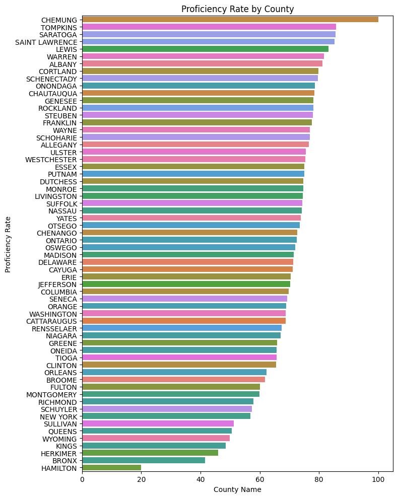

```python
# Imports
from scipy.stats import chi2_contingency # chi square test for hypothesis testing

# Calculate a proficiency rate column
df['proficiency_rate'] = df['proficient_student_cnt'] / df['tested_student_cnt'] * 100

# Organize by County Name
groups = [grp['proficiency_rate'].dropna() for _, grp in df.groupby('county_name')]

# Aggregate counts
county_counts = df.groupby('county_name')[['proficient_student_cnt', 'tested_student_cnt']].sum()
county_counts['not_proficient'] = county_counts['tested_student_cnt'] - county_counts['proficient_student_cnt']
print("Student Counts by County:")
print(county_counts)

# Contingency table
contingency_table = county_counts[['proficient_student_cnt', 'not_proficient']]

# Chi-squared test
chi2, p_value, dof, expected = chi2_contingency(contingency_table)
print("Chi2:", chi2)
print("p-value:", p_value)

# Sort by proficiency instead of county name, so we can clearly see the performance of counties comparatively
sorted_order = df.groupby('county_name')['proficiency_rate'].mean().sort_values(ascending=False).index

# Create bargraph
plt.figure(figsize=(8, 10))
sns.barplot(data=df, x='proficiency_rate', y='county_name', hue='county_name', legend=False, errorbar=None, order=sorted_order)

plt.title("Proficiency Rate by County")
plt.xlabel("County Name")
plt.ylabel("Proficiency Rate")
plt.tight_layout()
plt.show()
```

```python
# Highlight a few key values
print("Bronx Proficiency Rate:", df.groupby('county_name')["proficiency_rate"].mean().loc['BRONX'])
print("Hamilton Proficiency Rate:", df.groupby('county_name')["proficiency_rate"].mean().loc['HAMILTON'])
print("Albany Proficiency Rate:", df.groupby('county_name')["proficiency_rate"].mean().loc['ALBANY'])
print("Jefferson Proficiency Rate:", df.groupby('county_name')["proficiency_rate"].mean().loc['JEFFERSON'])
```

```
Bronx Proficiency Rate: 41.531077570108664
Hamilton Proficiency Rate: 20.0
Albany Proficiency Rate: 81.24368932506421
Jefferson Proficiency Rate: 70.37216271841928
```

Some thing one might notice from this chart is that the county Chemung has a suspiciously high proficiency rate of 100! We should take a closer look at this data point to make sure there is a sufficient number of data points in this category in order to make this a valid rate.

```python
# Check the number of test scores reported from Chemung
print(df[df['county_name'] == 'CHEMUNG']['tested_student_cnt'].sum())
```

```
4263
```

From this we see 4263 tests reported from Chemung, this is a sufficient amount and we can conclude that this reported 100 is indeed likely representitive and not the results of a small data pool, meaning we can continue with our analysis.

### Exploratory Analysis 2: Proficiency Rates by Race/Ethnicity

Next, we will look at **Proficiency Rate by Race/Ethnicity** across New York. Our goal with this analysis is to determine whether or not demographics are an indicator of performance in AP/IB testing. This addresses the question of an opportunity gap, and seeing as there is a statistical significance on geography's influence on proficiency rate from our first analysis, this can help determine what groups within those schools need more support.

**Hypothesis:**

- **H₀**: There is no significant difference in AP/IB proficiency rates between different racial/ethnic student subgroups.
- **Hₐ**: There is a significant difference in AP/IB proficiency rates between at least two racial/ethnic student subgroups.

**alpha level**: 0.05

**Dataset Characteristics:**

The original dataset contains a `subgroup_name` column that includes various demographic and socieoeconomic categories (e.g., "All Students", "Female", "Hispanic", "Economically Disadvantaged"). To perform a valid analysis, we first need to filter the data to isolate only the racial and ethnic subgroups, removing aggregate categories like "All Students" or gender-based groups to avoid double-counting.

These groups are:

- American Indian/Alaska Native
- Black
- Hispanic
- Asian/Pacific Islander
- White
- Multiracial

We chose a One-way ANOVA (Analysis of Variance) for this analysis as we are comparing a continuous variable (`proficiency_rate`) across more than two independent categorical groups (racial/ethnic subgroups). This statistical test allows us to determine if the variation between the group means is statistically significant compared to the variation within the groups. We will also create a box plot showing the AP/IB Proficiency Rates by Racial/Ethnic groups.

Consider visiting the following site for more information on the One-way ANOVA: https://www.jmp.com/en/statistics-knowledge-portal/one-way-anova

```
One-way ANOVA results:
F-statistic: 1591.5118
P-value: 0.0000
```

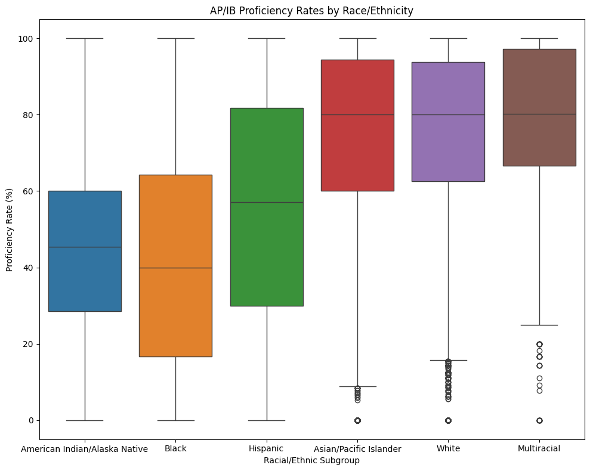

```python
# Filter by Racial/Ethnic Subgroups ONLY
filtered_subgroups = [
    'American Indian/Alaska Native',
    'Black',
    'Hispanic',
    'Asian/Pacific Islander',
    'White',
    'Multiracial'
]

# Create a subset dataframe copy filtered by race/ethnicity
df_race = df[df['subgroup_name'].isin(filtered_subgroups)].copy()

# Organize and group data by race/ethnicity subgroups
groups = [grp['proficiency_rate'].dropna() for _, grp in df_race.groupby('subgroup_name')]

# Perform One-Way ANOVA
f_stat, p_val = stats.f_oneway(*groups)
print(f"One-way ANOVA results:")
print(f"F-statistic: {f_stat:.4f}")
print(f"P-value: {p_val:.4f}")

# Visualization of Proficiency Rate by Race/Ethnicity Through a Box Plot
plt.figure(figsize=(10, 8))
sns.boxplot(y='proficiency_rate', x='subgroup_name', data=df_race, hue='subgroup_name')
plt.title('AP/IB Proficiency Rates by Race/Ethnicity')
plt.ylabel('Proficiency Rate (%)')
plt.xlabel('Racial/Ethnic Subgroup')
plt.tight_layout()
plt.show()
```

**Results:**

After performing a One-Way ANOVA test, we found a p-value of 0.00 (p < 0.001), significantly less than the alpha level of 0.05, which means **we reject the null hypothesis** and conclude it is statistically significant that **there is a significant difference in AP/IB Proficiency Rates between Racial/Ethnic Subgroups.** With a massive F-statistic of 1591.51, we see a profound disparity between racial demographics.

**Insights:**

We see that a student's racial/ethnic background is a statistically significant factor in their likelihood of achieving proficiency on AP/IB exams, validating the concerns of opportunity gaps in our introduction. These gaps are very real and statistically undeniable; and shows that demographic factors also highly influence student performance, not just geography. While it is important to identify what areas in the state are underserved, as property taxes influence school funding, it is also important to determine who within those school populations are in need of more resources. There is a great disparity between Asians/White/Multiracial students and American Indian/Black/Hispanic students, who are historically underserved.

### Exploratory Analysis 3: Proficiency Rates by Need/Resource Category

Finally, we look at **Proficiency by Need/Resource Category**

**Hypothesis:**

- **H₀**: Student proficiency rates are independent of need/resource category.
- **Hₐ**: Student proficiency rates depend on need/resource category.

**Alpha level:** 0.05

**Dataset Characteristics:**

However, certain NRC categories are over-represented in terms of total student counts, which could influence the statistical power of the chi-square test. The chi-square test was chosen as one of our analysis techniques because...

- We are comparing categorical data (NRC categories) against count data (proficient vs non-proficient students)
- We want to test for independence between two categorical variables
- The sample sizes are sufficiently large for chi-square assumptions

```
Student Counts by NRC Category:
                           proficient_student_cnt  non_proficient_cnt
nrc_desc
AVERAGE NEEDS                             1527782              519461
CHARTER SCHOOL                              11989               23589
LARGE CITY                                  71476               88930
LOW NEEDS                                 2411201              597130
NEW YORK CITY                             1982320             1342000
RURAL HIGH NEEDS                            44263               27132
URBAN/SUBURBAN/HIGH NEEDS                  164702              138574

Chi-Square Statistic: 441972.9436
P-value: 0.000000
```

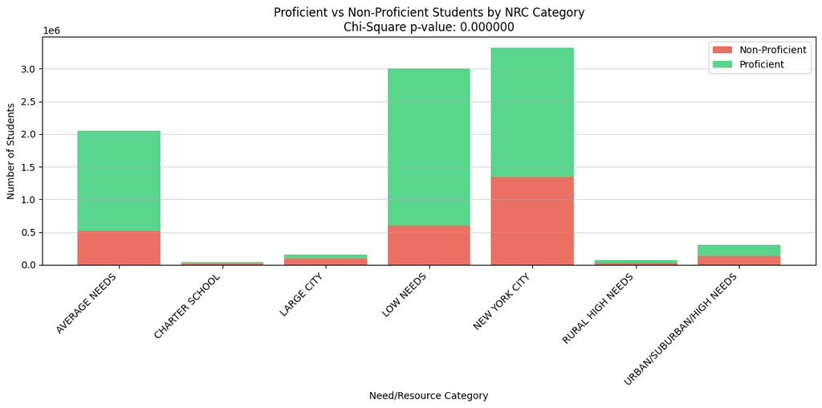

```python
# Calculate not proficient count
df['non_proficient_cnt'] = df['tested_student_cnt'] - df['proficient_student_cnt']
nrc_summary = df.groupby('nrc_desc')[['proficient_student_cnt', 'non_proficient_cnt']].sum()
print("Student Counts by NRC Category:")
print(nrc_summary)

# Actual chi-square test
chi2, p_value, dof, expected = chi2_contingency(nrc_summary.T)

print(f"\nChi-Square Statistic: {chi2:.4f}")
print(f"P-value: {p_value:.6f}")

# Chart showing percents of profecient per ncr
categories = nrc_summary.index
non_prof = nrc_summary['non_proficient_cnt'].values
prof = nrc_summary['proficient_student_cnt'].values

plt.figure(figsize=(12, 6))
x = np.arange(len(categories))

plt.bar(x, non_prof, label='Non-Proficient', color='#e74c3c', alpha=0.8)
plt.bar(x, prof, bottom=non_prof, label='Proficient', color='#2ecc71', alpha=0.8)

plt.xlabel('Need/Resource Category')
plt.ylabel('Number of Students')
plt.title(f'Proficient vs Non-Proficient Students by NRC Category\nChi-Square p-value: {p_value:.6f}')
plt.xticks(x, categories, rotation=45, ha='right')
plt.legend()
plt.grid(axis='y', alpha=0.5)
plt.tight_layout()
plt.show()
```

**Results:**

After running the test, we found a p-value of 0.00 (p < 0.001), significantly less than the alpha level of 0.05, so we reject the null hypothesis and conclude that there is a statistically significant relationship between school resource category and student proficiency rates. The visualization clearly shows that proficiency rates vary substantially across NRC categories. For example, based on the summary...

- **LOW NEEDS** districts have a much higher percentage of proficient students ( ≈ 80%) compared to non-proficient students ( ≈ 20%).
- **NEW YORK CITY** has a more even distribution, with a large percentage of proficient ( ≈ 59%) and non-proficient ( ≈ 41%) students.
- **CHARTER SCHOOL** have a significantly lower percentage of proficient students ( ≈ 33%) compared to non-proficient students ( ≈ 67%).

This indicates that resource allocation and need levels are strongly correlated with AP/IB student performance outcomes, highlighting significant equity gaps in advanced coursework access and success.

## **Primary Analysis**

From our exploratory data analysis we know there is significant impact that counties (made up of many districts) and racial demographics have on proficiency. An easy extension of this is to see how districts may be grouped into groups in order to determine which school districts need support for their progrmams.

We will be using the machine learning technique **K-means clustering** to identify patterns across New York school districts based on AP/IB exam performance. This choice is driven by the nature of our research questions and the structure of our dataset, unlike classification or regression tasks where we would predict a known outcome variable, our objective is to discover natural groupings within the data that may not be immediately obvious. We want to understand how districts naturally group together based on multiple performance and demographic factors simultaneously. K-means clustering is specifically designed for this type of unsupervised learning problem–finding structure in data without pre-defined labels.

Each school district can be categorized into numerous features:

- **Performance metrics:** Avg AP/IB scores, percentage of students receiving passing (college qualified) scores (AP >= 3, IB >= 4)
- **Access metrics:** number of different exams offered
- **Demographic factors:** percentage of economically disadvantaged, racial/ethnic diversity, household situation (homeless, single parent)
- **General Resource indicators:** Need Resource Category

By grouping districts into clusters, we can identify distinct profiles that can help us answer our proposed questions:

- **High-performing, high-access** districts may serve as models for best practices
- **High-potential** districts (high-access but lower scores) might benefit from teacher training and curriculum support
- **Low-access** districts (minimal AP/IB offerings) require investment in program infrastructure
- **High-need** districts (low performance across metrics) may need comprehensive support including funding, staffing, and resources

These cluster-based insights are more actionable than simple rankings or regression charts because they group districts with similar challenges, enabling policymakers to design interventions that address systemic issues shared by multiple communities. It will allow us to visualize where resources are lacking and which districts need more support.

Once districts are clustered, we can perform further analysis by examining demographic subgroup performance within each cluster. Some additional questions we can look at answering are:

- Do economically disadvantaged students perform differently in high-performing versus low-performing clusters?
- Are certain racial/ethnic groups underrepresented in AP/IB participation across all clusters, or is this issue concentrated in specific district types?
- Which clusters show the largest achievement gaps between demographic subgroups?

Our plan to implement K-means analysis will include multiple steps resulting in many plots to help us understand our data better.

- **Feature engineering:** first, we need to aggregate our data by district, keeping features from the exam-level data such as scores, demographic compositions, and NRC.
- **Feature Scaling:** Next, we standardize all features to ensure the variables with larger ranges don't dominate the clustering.
  - AP scores go up to 5, while IB goes up to 7 as while proficiency rate is a percentage 1 to 100.
- **Selection of K hyperparameter:** Since the goal of our research is to identify three groups (high, mid, and low performing) the elbow method is not necesary and we will set k to 3 to reflect this goal.
- **Cluster Validation:** Did we select the right clusters? Examine the cluster characteristics to ensure they are meaningful to providing insight into answering our questions

## Proficiency rate

We begin by importing the necessary tools from scikit-learn: **StandardScaler** for feature normalization and **KMeans** for clustering. Since our raw dataset contains individual exam records (one row per exam, grade, subgroup, etc), we aggregate all results to the district level by grouping by district_name and summing the total proficient and tested student counts across all exams.

We then calculate the proficiency rate--the percentage of students achieving college-credit scores (AP >= 3, IB >= 4)--which serves as our primary performance metric. This normalized metric allows fair comparison between large and small districts regardless of total exam volume.

```python
# Imports
from sklearn.preprocessing import StandardScaler
from sklearn.cluster import KMeans
import matplotlib.pyplot as plt
import seaborn as sns

# Add these features to your aggregation:
X = df.groupby('district_name').agg({
    'proficient_student_cnt': 'sum',
    'tested_student_cnt': 'sum',
    'test_name': 'nunique',  # Number of different exams offered (ACCESS)
    'nrc_desc': 'first',  # Needs/Resource category
    'county_name': 'first'
}).reset_index()

X['proficiency_rate'] = X['proficient_student_cnt'] / X['tested_student_cnt'] * 100
X['num_exams_offered'] = X['test_name']  # Rename for clarity
X['avg_students_per_exam'] = X['tested_student_cnt'] / X['num_exams_offered']

# Selection of features:
features = X[['proficiency_rate', 'num_exams_offered', 'avg_students_per_exam']]
```

We then standardize the proficiency rate using StandardScaler, which transforms the data to have **mean = 0** and s**tandard deviation = 1**. This is essential for K-means because the algorithm uses distance calculations; without standardization, features with larger numerical ranges (like IB scores, which range 1-7) would dominate the clustering process.

The resulting cluster assignments are added back to our district dataframe, allowing us to analyze cluster characteristics, examine geographic patterns, and investigate demographic factors associated with each performance tier.

```python
# Standardize features
scaler = StandardScaler()
X_scaled = scaler.fit_transform(features)

# K-means clustering
k = 3  # 3 clusters, high performing, mid, and low performing
kmeans = KMeans(n_clusters=k, random_state=42)
X['cluster'] = kmeans.fit_predict(X_scaled)

# Check cluster assignments
print(X[['district_name', 'cluster']])
```

```
               district_name  cluster
0                 ACADEMY CS        1
1       ACADEMY CS-UNIONDALE        1
2                      AKRON        2
3                     ALBANY        2
4    ALBANY LEADERSHIP-GIRLS        1
..                       ...      ...
489            WILLIAMSVILLE        2
490                  WINDSOR        1
491                  YONKERS        2
492        YORKSHIRE-PIONEER        1
493                 YORKTOWN        2

[494 rows x 2 columns]
```

## **Visualisation**

After applying K-means, we analyze the characteristics of each cluster to understand what distinguishes high, mid, and low-performing district groups. We calculate summary statistics (mean, min, max, count) for each cluster and create visualizations showing the distribution of proficiency rates.

The histogram reveals how proficiency rates are distributed within each cluster, while the box plot highlights differences in median performance and variance between groups.

Finally, we examine sample districts from each cluster to provide concrete examples of the types of districts grouped together, which helps validate that our clustering produced meaningful and interpretable results.

```
Cluster Summary Statistics:
        proficiency_rate
                    mean    min     max count
cluster
0                  62.82  38.42   90.46    22
1                  54.11  10.65   80.85   198
2                  80.21  53.43  100.00   274
```

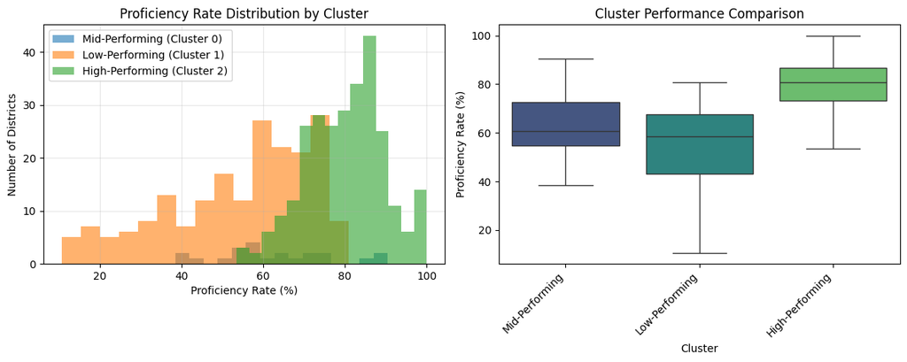

```
Sample Districts by Cluster:

Mid-Performing (Cluster 0):
                     district_name  proficiency_rate
49                         BUFFALO         38.417977
323    NYC GEOG DIST #27  - QUEENS         39.768296
313   NYC GEOG DIST #17 - BROOKLYN         43.097833
320     NYC GEOG DIST #24 - QUEENS         49.379949
300  NYC GEOG DIST # 4 - MANHATTAN         54.005568

Low-Performing (Cluster 1):
                    district_name  proficiency_rate
314  NYC GEOG DIST #18 - BROOKLYN         10.647773
319  NYC GEOG DIST #23 - BROOKLYN         10.829493
438                   TAPESTRY CS         13.930348
176   HARLEM VILLAGE ACADEMY EAST         14.400000
295        NUASIN NEXT GENERATION         15.299198

High-Performing (Cluster 2):
                    district_name  proficiency_rate
451                     UNIONDALE         53.430821
139                      FREEPORT         53.747589
311  NYC GEOG DIST #15 - BROOKLYN         53.822169
241                      LYNBROOK         56.809591
159                        GREECE         58.545079
```

```python
# Visualize cluster characteristics
cluster_summary = X.groupby('cluster').agg({
    'proficiency_rate': ['mean', 'min', 'max', 'count']
}).round(2)

print("Cluster Summary Statistics:")
print(cluster_summary)

# lables
cluster_names = {
    cluster_summary.loc[0]['proficiency_rate']['mean']: 'Mid-Performing',
    cluster_summary.loc[1]['proficiency_rate']['mean']: 'Low-Performing',
    cluster_summary.loc[2]['proficiency_rate']['mean']: 'High-Performing'
}

# sorting
sorted_cluster_means = sorted(cluster_names.keys())
cluster_id_to_name = {}
if 0 in cluster_summary.index:
    cluster_id_to_name[0] = cluster_names[cluster_summary.loc[0]['proficiency_rate']['mean']]
if 1 in cluster_summary.index:
    cluster_id_to_name[1] = cluster_names[cluster_summary.loc[1]['proficiency_rate']['mean']]
if 2 in cluster_summary.index:
    cluster_id_to_name[2] = cluster_names[cluster_summary.loc[2]['proficiency_rate']['mean']]

# distribution of proficiency rates by cluster (first plot)
plt.figure(figsize=(12, 5))

plt.subplot(1, 2, 1)
for cluster_id in sorted(X['cluster'].unique()):
    cluster_data = X[X['cluster'] == cluster_id]
    plt.hist(cluster_data['proficiency_rate'], alpha=0.6, label=f'{cluster_id_to_name[cluster_id]} (Cluster {cluster_id})', bins=15)
plt.xlabel('Proficiency Rate (%)')
plt.ylabel('Number of Districts')
plt.title('Proficiency Rate Distribution by Cluster')
plt.legend()
plt.grid(alpha=0.3)

# box plot comparing clusters
plt.subplot(1, 2, 2)
sns.boxplot(x='cluster', y='proficiency_rate', data=X, palette='viridis')
plt.xlabel('Cluster')
plt.ylabel('Proficiency Rate (%)')
plt.title('Cluster Performance Comparison')
plt.suptitle('')  # get rid of default title

# Set custom x-axis tick labels for the boxplot
plt.xticks(ticks=sorted(cluster_id_to_name.keys()), labels=[cluster_id_to_name[cid] for cid in sorted(cluster_id_to_name.keys())], rotation=45, ha='right')

plt.tight_layout()
plt.show()

# show sample districts from each cluster
print("\nSample Districts by Cluster:")
for cluster_id in sorted(X['cluster'].unique()):
    print(f"\n{cluster_id_to_name[cluster_id]} (Cluster {cluster_id}):")
    sample = X[X['cluster'] == cluster_id].nsmallest(5, 'proficiency_rate')
    print(sample[['district_name', 'proficiency_rate']])
```

## Raw Average Scores

We can also calculate the overall scores across districts to see which perform better overall. This normalized metric allows us to analyze which areas may are doing better and which ones may need more support solely off of raw exam scores.

```python
# Add these features to your aggregation:
X = df.groupby('district_name').agg({
    'level1_cnt': 'sum',
    'level2_cnt': 'sum',
    'level3_cnt': 'sum',
    'level4_cnt': 'sum',
    'level5_cnt': 'sum',
    'level6_cnt': 'sum',
    'level7_cnt': 'sum',
    'tested_student_cnt': 'sum',
    'test_name': 'nunique',  # Number of different exams offered (ACCESS)
    'nrc_desc': 'first',  # Needs/Resource category
    'county_name': 'first'
}).reset_index()

X['avg_score'] = (X['level1_cnt'] * 1 + X['level2_cnt'] * 2 +
                  X['level3_cnt'] * 3 + X['level4_cnt'] * 4 +
                  X['level5_cnt'] * 5 + X['level6_cnt'] * 6 +
                  X['level7_cnt'] * 7)/ X['tested_student_cnt']
X['num_exams_offered'] = X['test_name']  # Rename for clarity
X['avg_students_per_exam'] = X['tested_student_cnt'] / X['num_exams_offered']

# Selection of features:
features = X[['avg_score', 'num_exams_offered', 'avg_students_per_exam']]
```

The resulting cluster assignments are added back to our district dataframe, allowing us to analyze cluster characteristics, examine geographic patterns, and investigate demographic factors associated with each performance tier.

```python
# Standardize features
scaler = StandardScaler()
X_scaled = scaler.fit_transform(features)

# K-means clustering
k = 7  # 7 clusters, 1-7 score ranges
kmeans = KMeans(n_clusters=k, random_state=42)
X['cluster'] = kmeans.fit_predict(X_scaled)

# Check cluster assignments
print(X[['district_name', 'cluster']])
```

```
               district_name  cluster
0                 ACADEMY CS        1
1       ACADEMY CS-UNIONDALE        5
2                      AKRON        4
3                     ALBANY        3
4    ALBANY LEADERSHIP-GIRLS        5
..                       ...      ...
489            WILLIAMSVILLE        0
490                  WINDSOR        1
491                  YONKERS        0
492        YORKSHIRE-PIONEER        1
493                 YORKTOWN        2

[494 rows x 2 columns]
```

After applying K-means again, we can also analyze the characteristics of each cluster to understand what the raw average scores within each district. We calculate summary statistics (mean, min, max, count) for each cluster and create visualizations showing the distribution of the average scores.

The histogram reveals how raw exam scores are distributed within each cluster, while the box plot highlights differences in median performance and variance between groups.

Finally, we examine sample districts from each cluster to provide concrete examples of the types of districts grouped together, which helps validate that our clustering produced meaningful and interpretable results.

```
Cluster Summary Statistics:
        avg_score
             mean   min   max count
cluster
0            3.33  2.32  4.01    32
1            2.81  2.24   3.2   134
2            3.67  3.11  4.36    80
3            3.13  2.67  3.52    90
4            3.56  3.18  4.53   113
5            2.01  1.49  2.47    34
6            3.09  2.59  3.85    11
```

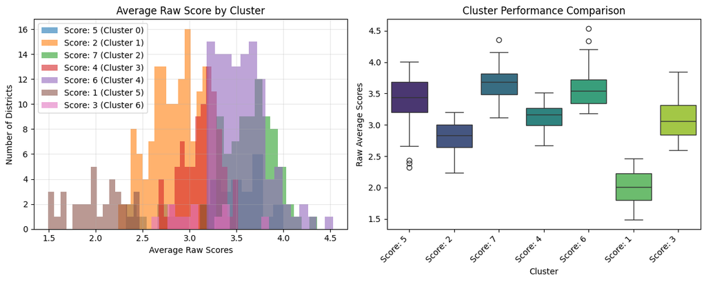

```
Sample Districts by Cluster:

Score: 5 (Cluster 0):
                     district_name  avg_score
323    NYC GEOG DIST #27  - QUEENS   2.319412
313   NYC GEOG DIST #17 - BROOKLYN   2.387902
49                         BUFFALO   2.437671
300  NYC GEOG DIST # 4 - MANHATTAN    2.65998
317   NYC GEOG DIST #21 - BROOKLYN   2.705739

Score: 2 (Cluster 1):
                  district_name  avg_score
151                GLOVERSVILLE       2.24
204  INWOOD ACADEMY- LEADERSHIP        2.3
195               HOOSIC VALLEY   2.349206
250               MARGARETVILLE   2.362903
103                     DEPOSIT    2.37037

Score: 7 (Cluster 2):
          district_name  avg_score
201          HUNTINGTON    3.11411
330           OCEANSIDE   3.150024
86   COLD SPRING HARBOR   3.289373
481   WESTHAMPTON BEACH   3.299829
415              SOMERS   3.316514

Score: 4 (Cluster 3):
                    district_name  avg_score
202                     HYDE PARK   2.666799
139                      FREEPORT   2.669744
451                     UNIONDALE    2.67929
69                  CENTRAL ISLIP   2.705128
311  NYC GEOG DIST #15 - BROOKLYN   2.756689

Score: 6 (Cluster 4):
        district_name  avg_score
290   NORTH TONAWANDA   3.178142
374         RHINEBECK   3.184411
436          SYRACUSE   3.184524
45   BROADALBIN-PERTH   3.191813
355         PINE BUSH    3.19649

Score: 1 (Cluster 5):
                    district_name  avg_score
319  NYC GEOG DIST #23 - BROOKLYN   1.491705
314  NYC GEOG DIST #18 - BROOKLYN   1.519433
203         INNOVATION CHARTER HS   1.531915
438                   TAPESTRY CS    1.59204
315  NYC GEOG DIST #19 - BROOKLYN   1.633049

Score: 3 (Cluster 6):
                    district_name  avg_score
320    NYC GEOG DIST #24 - QUEENS   2.593755
324    NYC GEOG DIST #28 - QUEENS   2.786141
316  NYC GEOG DIST #20 - BROOKLYN   2.826898
321    NYC GEOG DIST #25 - QUEENS   2.851871
405                     SEWANHAKA    2.95174
```

```python
import matplotlib.pyplot as plt
import seaborn as sns

# Visualize cluster characteristics
cluster_summary = X.groupby('cluster').agg({
    'avg_score': ['mean', 'min', 'max', 'count']
}).round(2)

print("Cluster Summary Statistics:")
print(cluster_summary)

# Get the mean scores for all clusters and sort them by value (ascending)
sorted_mean_scores_indices = cluster_summary['avg_score']['mean'].sort_values().index

# Create a mapping from sorted rank to a descriptive score label
rank_to_label = {cluster_id: f'Score: {i+1}' for i, cluster_id in enumerate(sorted_mean_scores_indices)}

# Create the cluster_id_to_name mapping using the new rank_to_label
cluster_id_to_name = {}
for cluster_id in cluster_summary.index:
    cluster_id_to_name[cluster_id] = rank_to_label[cluster_id]

# distribution of proficiency rates by cluster (first plot)
plt.figure(figsize=(12, 5))

plt.subplot(1, 2, 1)
for cluster_id in sorted(X['cluster'].unique()):
    cluster_data = X[X['cluster'] == cluster_id]
    plt.hist(cluster_data['avg_score'], alpha=0.6, label=f'{cluster_id_to_name[cluster_id]} (Cluster {cluster_id})', bins=15)
plt.xlabel('Average Raw Scores')
plt.ylabel('Number of Districts')
plt.title('Average Raw Score by Cluster')
plt.legend()
plt.grid(alpha=0.3)

# box plot comparing clusters
plt.subplot(1, 2, 2)
sns.boxplot(x='cluster', y='avg_score', data=X, palette='viridis')
plt.xlabel('Cluster')
plt.ylabel('Raw Average Scores')
plt.title('Cluster Performance Comparison')
plt.suptitle('')  # get rid of default title

# Set custom x-axis tick labels for the boxplot
plt.xticks(ticks=sorted(cluster_id_to_name.keys()), labels=[cluster_id_to_name[cid] for cid in sorted(cluster_id_to_name.keys())], rotation=45, ha='right')

plt.tight_layout()
plt.show()

# show sample districts from each cluster
print("\nSample Districts by Cluster:")
for cluster_id in sorted(X['cluster'].unique()):
    print(f"\n{cluster_id_to_name[cluster_id]} (Cluster {cluster_id}):")
    sample = X[X['cluster'] == cluster_id].nsmallest(5, 'avg_score')
    print(sample[['district_name', 'avg_score']])
```

## Further Analysis in Comparison to Overall Student Population

To further compare the scores, we wanted to look at the scores compared to the overall student population.

We used another data set from (https://data.nysed.gov/files/enrollment/23-24/enrollment_2024.zip), and converted the `ENROLL2024_20241105.mdb` into a .csv using Microsoft Excel, which gave us three .csv files from the tables within the dataset, which gave enrollment by grade, district, and demographics.

```python
# Read new CSV files
enrollment = pd.read_csv("/content/sample_data/BEDS Day Enrollment.csv")
district = pd.read_csv("/content/sample_data/BOCES and N_RC.csv")
demographics = pd.read_csv("/content/sample_data/Demographic Factors.csv")

# Only take what we need
enrollment = enrollment[['ENTITY_CD', '9', '10', '11', '12', 'YEAR']]
district = district[['ENTITY_CD', 'DISTRICT_NAME', 'YEAR']]
demographics = demographics[['ENTITY_CD', 'YEAR', 'NUM_FEMALE']]

# Merge all the files
enroll_df = pd.merge(
    enrollment,
    district,
    on=['ENTITY_CD', 'YEAR'],
    how='left'
)
enroll_df = pd.merge(
    enroll_df,
    demographics,
    on=['ENTITY_CD', 'YEAR'],
    how='left'
)

print(enroll_df.head)
print(enroll_df.shape)
enroll_df = enroll_df[enroll_df['YEAR'] < 2025]
enroll_df = enroll_df[enroll_df['YEAR'] > 2022]
enroll_df = enroll_df.dropna(subset=['9', '10', '11', '12', 'DISTRICT_NAME'])
print(enroll_df.shape)
print(enroll_df.head)
enroll_df = enroll_df.groupby('DISTRICT_NAME')[['9', '10', '11', '12', 'NUM_FEMALE']].sum()
enroll_df = enroll_df.reset_index() # Convert the index back to a column
enroll_df.shape
enroll_df.head()

enroll_df = enroll_df.rename(columns={'DISTRICT_NAME': 'district_name'})

df_merged = pd.merge(df, enroll_df, on='district_name', how='left')
df_merged.shape
df_merged.head()
```

```
<bound method NDFrame.head of           ENTITY_CD      9     10     11     12  YEAR DISTRICT_NAME  \
0                 1  71724  70858  63301  61348  2023           NaN
1                 2   8052   7316   6360   6430  2023           NaN
2                 3  16605  16244  14370  14181  2023           NaN
3                 4  11326  10424   9811   9571  2023           NaN
4                 1  73324  71091  64413  60613  2024           NaN
...             ...    ...    ...    ...    ...   ...           ...
16601  680601060002      0      0      0      0  2025  PENN YAN CSD
16602  680601060005      0      0      0      0  2025  PENN YAN CSD
16603  680801040000     46     58     39     37  2025           NaN
16604  680801040001     46     58     39     37  2025    DUNDEE CSD
16605  680801040002      0      0      0      0  2025    DUNDEE CSD

       NUM_FEMALE
0          384400
```

[output cut: 28 more lines]

|  | school_year | aggregation_index | aggregation_type | aggregation_code | aggregation_name | institution_ID | BEDS_district_ID | district_name | nrc_code | nrc_desc | ... | level5_cnt | level6_cnt | level7_cnt | proficiency_rate | non_proficient_cnt | 9 | 10 | 11 | 12 | NUM_FEMALE |
| --- | --- | --- | --- | --- | --- | --- | --- | --- | --- | --- | --- | --- | --- | --- | --- | --- | --- | --- | --- | --- | --- |
| 0 | 2023-24 | 0 | Statewide | 0 | NEW YORK STATE | <NA> | <NA> | NaN | <NA> | NaN | ... | 160 | 0 | 0 | 73.684211 | 125 | NaN | NaN | NaN | NaN | NaN |
| 1 | 2023-24 | 0 | Statewide | 0 | NEW YORK STATE | <NA> | <NA> | NaN | <NA> | NaN | ... | 860 | 0 | 0 | 75.301205 | 574 | NaN | NaN | NaN | NaN | NaN |
| 2 | 2023-24 | 0 | Statewide | 0 | NEW YORK STATE | <NA> | <NA> | NaN | <NA> | NaN | ... | 359 | 0 | 0 | 53.518519 | 1004 | NaN | NaN | NaN | NaN | NaN |
| 3 | 2023-24 | 0 | Statewide | 0 | NEW YORK STATE | <NA> | <NA> | NaN | <NA> | NaN | ... | 14 | 0 | 0 | 64.285714 | 15 | NaN | NaN | NaN | NaN | NaN |
| 4 | 2023-24 | 0 | Statewide | 0 | NEW YORK STATE | <NA> | <NA> | NaN | <NA> | NaN | ... | 686 | 0 | 0 | 81.285231 | 664 | NaN | NaN | NaN | NaN | NaN |

5 rows × 36 columns

Now, we can analyze the overall student population's proficiency rate

```python
# Imports
from sklearn.preprocessing import StandardScaler
from sklearn.cluster import KMeans
import matplotlib.pyplot as plt
import seaborn as sns

# Add these features to your aggregation:
X = df_merged.groupby('district_name').agg({
    'proficiency_rate': 'mean',
    'tested_student_cnt': 'sum',
    'test_name': 'nunique',  # Number of different exams offered (ACCESS)
    'nrc_desc': 'first',  # Needs/Resource category
    'county_name': 'first'
}).reset_index()

X['proficiency_rate'] = X['proficiency_rate']
X['num_exams_offered'] = X['test_name']  # Rename for clarity
X['avg_students_per_exam'] = X['tested_student_cnt'] / X['num_exams_offered']

# Selection of features:
features = X[['proficiency_rate', 'num_exams_offered', 'avg_students_per_exam']]
```

We then standardize the proficiency rate using StandardScaler, which transforms the data to have **mean = 0** and s**tandard deviation = 1**. This is essential for K-means because the algorithm uses distance calculations; without standardization, features with larger numerical ranges (like IB scores, which range 1-7) would dominate the clustering process.

We then apply K-means with **k=3** clusters to group districts into three performance tiers: **high-performing, mid-performing,** and **low-performing**. This matches the tiers we have for just the specific NY districts we looked at already.

The resulting cluster assignments are added back to our district dataframe, allowing us to analyze cluster characteristics, examine geographic patterns, and investigate demographic factors associated with each performance tier.

```python
# Standardize features
scaler = StandardScaler()
X_scaled = scaler.fit_transform(features)

# K-means clustering
k = 3  # 3 clusters, low, mid, high-performing
kmeans = KMeans(n_clusters=k, random_state=42)
X['cluster'] = kmeans.fit_predict(X_scaled)

# Check cluster assignments
print(X[['district_name', 'cluster']])
```

```
               district_name  cluster
0                 ACADEMY CS        1
1       ACADEMY CS-UNIONDALE        1
2                      AKRON        2
3                     ALBANY        2
4    ALBANY LEADERSHIP-GIRLS        1
..                       ...      ...
489            WILLIAMSVILLE        2
490                  WINDSOR        1
491                  YONKERS        2
492        YORKSHIRE-PIONEER        1
493                 YORKTOWN        2

[494 rows x 2 columns]
```

After applying K-means again, we can also analyze the characteristics of each cluster to understand what the proficiency rate is throughout all the districts. We calculate summary statistics (mean, min, max, count) for each cluster and create visualizations showing the distribution of the average scores.

The histogram reveals how these proficiency rates are distributed within each cluster, while the box plot highlights differences in median performance and variance between groups.

Finally, we examine sample districts from each cluster to provide concrete examples of the types of districts grouped together, which helps validate that our clustering produced meaningful and interpretable results.

```
Cluster Summary Statistics:
        proficiency_rate
                    mean    min     max count
cluster
0                  57.74  32.71   90.03    22
1                  56.35  10.46   85.19   212
2                  80.30  55.56  100.00   260
```

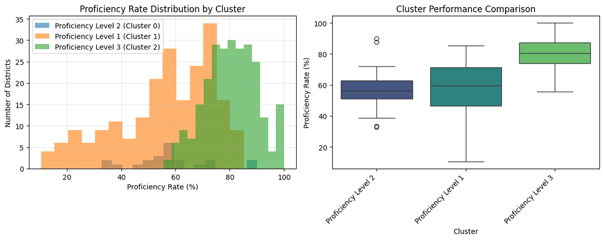

```
Sample Districts by Cluster:

Proficiency Level 2 (Cluster 0):
                    district_name  proficiency_rate
49                        BUFFALO         32.706916
313  NYC GEOG DIST #17 - BROOKLYN         33.387915
323   NYC GEOG DIST #27  - QUEENS         38.662782
320    NYC GEOG DIST #24 - QUEENS         47.411694
326    NYC GEOG DIST #30 - QUEENS         50.727544

Proficiency Level 1 (Cluster 1):
                    district_name  proficiency_rate
319  NYC GEOG DIST #23 - BROOKLYN         10.461147
438                   TAPESTRY CS         11.427469
314  NYC GEOG DIST #18 - BROOKLYN         12.322061
176   HARLEM VILLAGE ACADEMY EAST         12.890284
295        NUASIN NEXT GENERATION         15.682644

Proficiency Level 3 (Cluster 2):
                  district_name  proficiency_rate
451                   UNIONDALE         55.564876
149                   GLEN COVE         58.375204
491                     YONKERS         59.289129
100                   DEER PARK         59.359463
48   BROOKHAVEN-COMSEWOGUE UFSD         60.400516
```

```python
# Visualize cluster characteristics
cluster_summary = X.groupby('cluster').agg({
    'proficiency_rate': ['mean', 'min', 'max', 'count']
}).round(2)

print("Cluster Summary Statistics:")
print(cluster_summary)

# Get the mean proficiency rates for all clusters and sort them by value (ascending)
sorted_mean_rates_indices = cluster_summary['proficiency_rate']['mean'].sort_values().index

# Create a mapping from sorted rank to a descriptive proficiency label
# Since k=3, we can label them sequentially or based on tiers if we define more specific ranges.
# For now, let's use a generic 'Proficiency Level X' label.
rank_to_label = {cluster_id: f'Proficiency Level {i+1}' for i, cluster_id in enumerate(sorted_mean_rates_indices)}

# Create the cluster_id_to_name mapping using the new rank_to_label
cluster_id_to_name = {}
for cluster_id in cluster_summary.index:
    cluster_id_to_name[cluster_id] = rank_to_label[cluster_id]

# distribution of proficiency rates by cluster (first plot)
plt.figure(figsize=(12, 5))

plt.subplot(1, 2, 1)
for cluster_id in sorted(X['cluster'].unique()):
    cluster_data = X[X['cluster'] == cluster_id]
    plt.hist(cluster_data['proficiency_rate'], alpha=0.6, label=f'{cluster_id_to_name[cluster_id]} (Cluster {cluster_id})', bins=15)
plt.xlabel('Proficiency Rate (%)')
plt.ylabel('Number of Districts')
plt.title('Proficiency Rate Distribution by Cluster')
plt.legend()
plt.grid(alpha=0.3)

# box plot comparing clusters
plt.subplot(1, 2, 2)
sns.boxplot(x='cluster', y='proficiency_rate', data=X, palette='viridis')
plt.xlabel('Cluster')
plt.ylabel('Proficiency Rate (%)')
plt.title('Cluster Performance Comparison')
plt.suptitle('')  # get rid of default title

# Set custom x-axis tick labels for the boxplot
plt.xticks(ticks=sorted(cluster_id_to_name.keys()), labels=[cluster_id_to_name[cid] for cid in sorted(cluster_id_to_name.keys())], rotation=45, ha='right')

plt.tight_layout()
plt.show()

# show sample districts from each cluster
print("\nSample Districts by Cluster:")
for cluster_id in sorted(X['cluster'].unique()):
    print(f"\n{cluster_id_to_name[cluster_id]} (Cluster {cluster_id}):")
    # Ensure 'proficiency_rate' is a valid column to sort by
    sample = X[X['cluster'] == cluster_id].nsmallest(5, 'proficiency_rate')
    print(sample[['district_name', 'proficiency_rate']])
```

## **Insights and Conclusion**

From our analysis, we can conclude that for the Low-Performing cluster, policy effort must prioritize allocating more funding and improving more access to better educational resources, as these districts require more comprehensive support to build foundational advanced coursework infrastucture and equity programs. We can also conclude that for the Mid-Performing cluster, the policy effort should shift to optimizing better support such as more effective teacher training and curriculum reform similar to the High-Performing cluster to raise proficiency rates. As we have also identified demographic gaps in opportunity from the ANOVA, targeted funding should account for said demographic gaps, ensuring resources are directed not just to "low/mid-performing" schools generally, but to the specific student subgroups that we have identified are being systematically underserved.